# Computational Statistics 12.3: Clustering

## Clustering

### Overview

This lesson introduces clustering

### Objectives

After completing this module, students should be able to:

1. Explain the meaning of clusters.
2. Calculate clusters using k means and interpret the results.
3. Calculate clusters using hierarchical clustering and choose cluster sizes.

### Readings

Lander, 22.1, 22.3

## Cluster analysis

- Cluster analysis is an alternative form of unsupervised learning, with perhaps as long and complex a lineage as factor analysis.
- Generally targeted at the observation level.
- This methodology groups observations into certain clusters, based on how similar observations are.
- We’ll often see a strong overlap between clusters and factors, but a key difference is that factors are inherently dimensional and opposites: there are two directions for every factor, and we often see clear oppositions at either end.
- Clusters are less about opposite positions and more about finding commonality among different groups of observations. Also, you can have as many clusters as observations in the data, but only components as many variables.

### Example

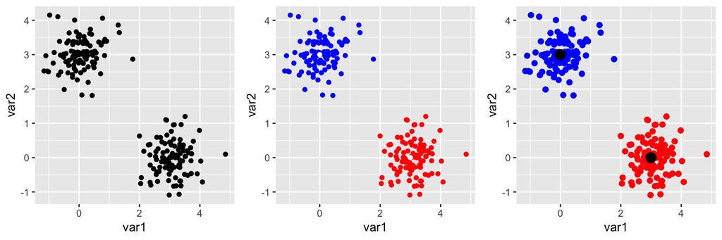

- Here we have an *original* dataset without any cluster classification (left), but it simply inspecting the scatter plot we can visually identify two clouds of data that gather around in two different locations.
- The second group shows the cluster classification that best fit the data (center). Red observations are assigned to group 1, and blue to group2.
- In the jargon of factor analysis, we can say that group 1 loads heavily on variable 1 (the $x$ axis) and group 2 loads heavily on variable 2 (the$ y$ axis).
- But, in the language of cluster analysis, we’ll define the groups by their centers: the black dots in the figure at the right.
  - The center of the red group is (3,0) and the center of the left is (0,3), making precise our notion of how the cluster identities are defined by the two variables (axes). We can then characterize red observations as being *relatively high* in $x$ and *relatively low* in $y$ and blue observations *relatively high* in $y$ and *relatively low* in $x$.
  - And the group centers even allow us to define who belongs to which group: those nearest the (0,3) center belong the the blue group, and those nearest the (3,0) center belong to the red group. Then, besides summarizing the information of the dataset, clustering provides an automatic and immediate classification of each observation.
  - In a sense, the group defines the center point, and the center point defines the group (ie, those closest to that point).
- Then, we need to find a method that allow us to simultaneously define the clusters’ centers and classify the observations.

## K Means Algorithm

The *k-means* algorithm is the most long-established unsupervised machine learning algorithm. Is a surprisingly simple but very powerful algorithm. We have to specify first how many clusters we want to create, and then the algorithm will figure out what are the centers for each cluster and classify each observation accordingly.

This is a summary of how the algorithm works:

1. Select the number of clusters ($k$) you want to create.
2. Let the computer selects randomly $k$ observations from the data, this $k$ observations will be the initial centers of the $k$ clusters.
3. For each observation in the data, assign that observation to the closer cluster center (centroid). This will then classify each observation in the nearest cluster center.
4. For each of the $k$ clusters, compute the average value of the observations in the cluster. Let this be the new cluster center for the cluster.
5. Iteratively minimize the total within cluster sum of square. That is, iterate steps 3 and 4 until the difference between each observation in a cluster are as small as possible with the given number of clusters.

That’s it! Now each group (= cluster) is represented by its center (= **centriod:** the mean of points assigned to the clusters).

### Example

If you were confused by how the algorithm works, let me go over a couple of iterations manually so you get to see how the algorithm works before using it.

Imagine that we have the following two variables and we want to cluster the data into two groups:

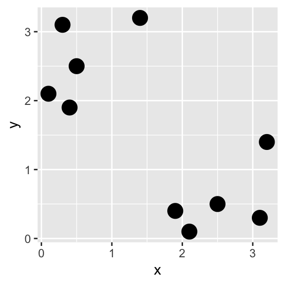

```r
x <- c(0.1, 1.4, 0.5, 0.4, 0.3, 2.1, 3.2 , 2.5, 1.9, 3.1)
y <- c(2.1, 3.2 , 2.5, 1.9, 3.1, 0.1, 1.4, 0.5, 0.4, 0.3)
data <- data.frame(x,y)
ggplot(data,aes(x=x,y=y)) + geom_point(size = 5)
```

- First, let’s find select some random initial cluster centers

```r
set.seed(1)
n <- 10 # Number of observations
k <- 2 # Number of clusters
obsIndex <- sample(1:n, 2, replace = FALSE)
c_k <- data[obsIndex,] # Initial Centers
c_k
```

```
##     x   y
## 3 0.5 2.5
## 4 0.4 1.9
```

Then, we find the distance to each of this centers. We can use the `dist` function to find the distance between different points.

```r
dist <- as.matrix(dist(data)) # Distance
distToClusterOne <- dist[obsIndex[1],]
distToClusterTwo <-dist[obsIndex[2],]
cbind(distToClusterOne, distToClusterTwo)
```

```
##    distToClusterOne distToClusterTwo
## 1         0.5656854        0.3605551
## 2         1.1401754        1.6401219
## 3         0.0000000        0.6082763
## 4         0.6082763        0.0000000
## 5         0.6324555        1.2041595
## 6         2.8844410        2.4758837
## 7         2.9154759        2.8442925
## 8         2.8284271        2.5238859
## 9         2.5238859        2.1213203
## 10        3.4058773        3.1384710
```

Now we classify each observations into a cluster using the minimum distance.

```r
clusterClass <- apply(cbind(distToClusterOne, distToClusterTwo), 1, FUN = function(x) which(x == min(x)))
clusterClass
```

```
##  1  2  3  4  5  6  7  8  9 10
##  2  1  1  2  1  2  2  2  2  2
```

This is how the initial random cluster classification looks like.

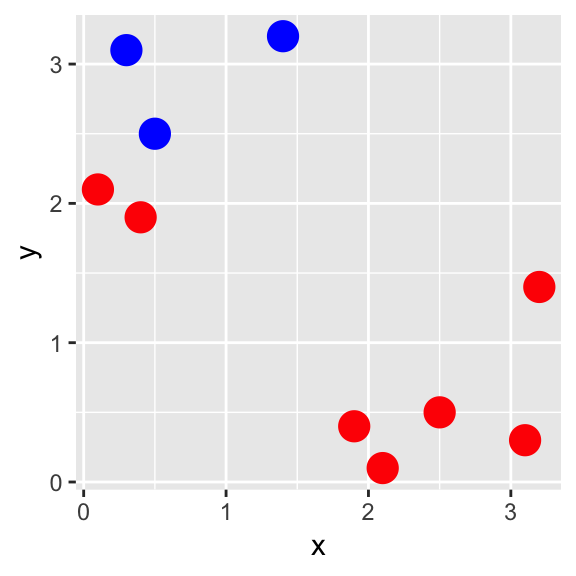

```r
data <- data.frame(x,y, clusterClass)
ggplot(data,aes(x=x,y=y, color = as.factor(clusterClass))) + geom_point(size = 5)  + theme(legend.position="none") + scale_color_manual(values=c("blue","red"))
```

Then, we know that obsertions with 1 belong to the first cluster and observations with 2 belong to the second cluster. Now we can compute the new cluster centers.

```r
# Getting center of first cluster
c_k[1,] <- colMeans(data[clusterClass == 1,])
# Getting center of second cluster
c_k[2,] <- colMeans(data[clusterClass == 2,])
c_k
```

```
##           x         y
## 3 0.7333333 2.9333333
## 4 1.9000000 0.9571429
```

See how the cluster centers moved? next step is to compute the distance again for each observation, classify them, and compute new centers. We’ll repeat this process until the centers don’t really change much. But doing this manually can take a lot of time, that’s why we prefer to program the algorithm or use a built-in function. I’ll display below a graph using the classification using the new centers.

```r
distToClusterOne <- apply(data, 1, FUN = function(x) dist(rbind(x, c_k[1,])))
distToClusterTwo <- apply(data, 1, FUN = function(x) dist(rbind(x, c_k[2,])))
clusterClass <- apply(cbind(distToClusterOne, distToClusterTwo), 1, FUN = function(x) which(x == min(x)))
clusterClass
```

```
##  1  2  3  4  5  6  7  8  9 10
##  1  1  1  1  1  2  2  2  2  2
```

[figure not shown]

```r
ggplot(data,aes(x=x,y=y, color = as.factor(clusterClass))) + geom_point(size = 5)  + theme(legend.position="none") + scale_color_manual(values=c("blue","red"))
```

Pretty good! Hopefully now you have an intuitive idea of how the algorithm works.

### K-means algorithm

- There are, as usual, plenty of variations to the previously described algorithm. Especially in the way one compute the distance to the cluster centroid:
- A common one is the Hartigan-Wong algorithm (1979): **total within-cluster variation**

$$W(C_k) = \sum_{x_i\in{C_k}}(x_i - \mu_k)^2$$
where $x_i$ represents each data point that gets assigned to a cluster $C_k$ and $\mu_k$ is the mean value of the points assigned to the cluster.

- And we use $W(C_k)$ to **minimize the sum of squares distance** of the observation to the assigned cluster centers:

$$\text{Total within sum of squares} = \sum^{k}_{k=1}W(C_k) = \sum^{k}_{k=1} \sum_{x_i\in C_k} (x_i - \mu_k)^2$$

### Clustering distance measures

- We want clusters that have a high **within similarity**.
- This requires utilizing a certain distance measure, most commonly (and in `R` the default) is the **Euclidean distance** as shown in the example:

$$d_{euc}(x,y) = \sqrt{\sum^n_{i=1}(x_i - y_i)^2}$$

- There are plenty of other distance measures (e.g. some are based on correlations instead of distance).

## K-means in R

`R` of course has its own routines for estimating k means clusters: `kmeans`. Which makes the process of finding clusters less tedius. Let’s apply it to the data from the previous example.

```r
kout <- kmeans(data, centers = 2)
kout
```

```
## K-means clustering with 2 clusters of sizes 5, 5
##
## Cluster means:
##      x    y clusterClass
## 1 2.56 0.54          2.0
## 2 0.54 2.56          1.4
##
## Clustering vector:
##  1  2  3  4  5  6  7  8  9 10
##  2  2  2  2  2  1  1  1  1  1
##
## Within cluster sum of squares by cluster:
## [1] 2.364 3.564
##  (between_SS / total_SS =  78.2 %)
##
## Available components:
##
## [1] "cluster"      "centers"      "totss"        "withinss"
## [5] "tot.withinss" "betweenss"    "size"         "iter"
## [9] "ifault"
```

That’s it! we can then extract the cluster classification or the centers using `$`.

```r
kcenters <- kout$centers
kcenters
```

```
##      x    y clusterClass
## 1 2.56 0.54          2.0
## 2 0.54 2.56          1.4
```

```r
kclass <- kout$cluster
kclass
```

```
##  1  2  3  4  5  6  7  8  9 10
##  2  2  2  2  2  1  1  1  1  1
```

And we can use the classification to visualize the clusters.

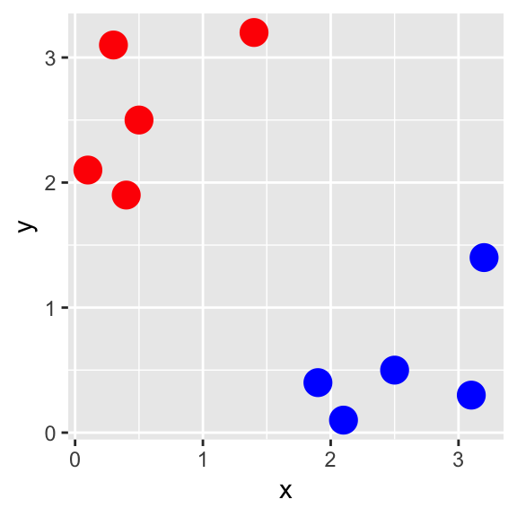

```r
ggplot(data,aes(x=x,y=y, color = as.factor(kclass))) + geom_point(size = 5)  + theme(legend.position="none") + scale_color_manual(values=c("blue","red"))
```

### Psych data (example)

To illustrate the other things we can do with `kmeans` we’ll use the Motivational State Questionnaire data from the previous learnign module. Let’s prepare the data,

```r
#install.packages("psych")
library(psych)
msq1 <- msq[,2:72] # cluster on meaningful columns, here "emotions" or "sentiments"
msq1[msq1=="9"] = NA # recode values that need to be interpreted as missing
msq1 <- data.frame(msq1)
msq2 <- na.omit(msq1) # drop missing values
```

### Kmeans with psych data (1/4)

Let’s try the `kmeans` function on the dataset, we are going to assume that there are two clusters in the data, so we add the option `centers = 2`:

```r
kout <- kmeans(msq2, centers=2)
```

That’s it. But there is a problem, the algorithm depends on the initial condition.

- Ideally we want the best assignment, where the best assignment is the placement of centroids such that the total variance within each group is minimized.
- Since the result of the k means algorithm can depend on the starting conditions, the `kmeans` function can automatically take a set of different initial conditions, run the whole algorithm with each initial condition, and report the best of the run.
- We run it with 25 random starts (`nstart=25`)

```r
kout <- kmeans(msq2,centers=2,nstart=25)
```

### Kmeans with psych data (2/4)

- We can inspect the group memberships, but that’s a little hard to parse with 71 variables and thousands of observations. Easier to interpret is the location of the centroids in the 71 dimensions.
- This might seems like a lot, but we assigned only two centers, each of which is in a 71-dimensional space (just as the two centroids in the previous example were in a 2-dimensional space).
- What we generally want to know is; for each centroid, what dimensions does it score particularly highly on? To answer this question we can just sort each centroid by its scores on all 71 variables, and display the top scoring variables:

```r
centroids <- kout$centers #Extracting cluster centers
topvars_centroid1 <- centroids[1,order(centroids[1,])] # Sorting by 1 centroid
topvars_centroid2 <- centroids[2,order(centroids[2,])] # Sorting by 2 centroid
tail(topvars_centroid1)
```

```
  satisfied       happy    sociable   confident     content warmhearted
   1.889350    1.950207    1.957123    1.976487    1.993084    1.994467
```

```r
tail(topvars_centroid2)
```

```
  drowsy sluggish    bored    quiet   sleepy    tired
1.578125 1.589844 1.593750 1.625977 1.694336 1.858398
```

Looks familiar? The second cluster seems to be the sleep/tired individuals, and the first cluster is the *happy* cluster, although it seems more about content and happy than about energetic and happy, as we saw in the first principal component.

- In which of the two groups you find yourself before and after submitting the weekly hw? happy or sleep/tired?

### Kmeans with psych data (3/4)

We can get additional summary metrics:

```r
str(kout)
```

```
List of 9
 $ cluster     : Named int [1:1747] 2 2 2 1 2 2 1 2 2 1 ...
  ..- attr(*, "names")= chr [1:1747] "1" "2" "3" "4" ...
 $ centers     : num [1:2, 1:71] 0.109 0.148 1.775 0.679 0.113 ...
  ..- attr(*, "dimnames")=List of 2
  .. ..$ : chr [1:2] "1" "2"
  .. ..$ : chr [1:71] "afraid" "alert" "angry" "anxious" ...
 $ totss       : num 82807
 $ withinss    : num [1:2] 26791 39897
 $ tot.withinss: num 66688
 $ betweenss   : num 16119
 $ size        : int [1:2] 723 1024
 $ iter        : int 1
 $ ifault      : int 0
 - attr(*, "class")= chr "kmeans"
```

Now let’s run it with three clusters and compare total within sum of squares.

```r
kout3 <- kmeans(msq2,centers=3,nstart=25)
kout3$tot.withinss
```

```
[1] 61505.46
```

```r
kout$tot.withinss
```

```
[1] 66687.6
```

Three clusters seems to do a better job in minimizing the sum of squares distance.

### Kmeans with psych data (4/4)

Also, we can examine what variables each cluster score high on directly:

```r
out <- sapply(1:3, FUN = function(x) round(colMeans(msq2[kout3$cluster == x,]),2))
colnames(out) <- paste("Cluster:", 1:3, sep = " ")
clusterVars <- apply(out, 1, FUN = function(x) which(x == max(x)))

# This are the variables that score high
# for cluster 1
colnames(msq2)[clusterVars == 1]
```

```
 [1] "afraid"      "angry"       "anxious"     "ashamed"     "blue"
 [6] "bored"       "clutched.up" "depressed"   "distressed"  "drowsy"
[11] "dull"        "fearful"     "frustrated"  "gloomy"      "grouchy"
[16] "guilty"      "hostile"     "irritable"   "lonely"      "nervous"
[21] "quiet"       "sad"         "scared"      "sleepy"      "sluggish"
[26] "sorry"       "tense"       "tired"       "unhappy"     "upset"
```

```r
# This are the variables that score high
# for cluster 2
colnames(msq2)[clusterVars == 2]
```

```
[1] "calm"     "idle"     "inactive" "placid"   "serene"   "still"
[7] "tranquil"
```

```r
# This are the variables that score high
# for cluster 3
colnames(msq2)[clusterVars == 3]
```

```
 [1] "alert"        "aroused"      "astonished"   "at.ease"
 [5] "at.rest"      "attentive"    "cheerful"     "confident"
 [9] "content"      "delighted"    "determined"   "elated"
[13] "energetic"    "enthusiastic" "excited"      "full.of.pep"
[17] "happy"        "inspired"     "intense"      "interested"
[21] "jittery"      "lively"       "pleased"      "proud"
[25] "quiescent"    "relaxed"      "satisfied"    "sociable"
[29] "strong"       "surprised"    "vigorous"     "wakeful"
[33] "warmhearted"  "wide.awake"
```

Using the 3 centers, the cluster classification seems to group individuals by: (1) negative feelings, (2) calmness/tranquility, and, (3) positive feelings. Note that the classification of (1) and (3) is a bit ambiguous, maybe we need more cluster centers to make understand their difference better.

## Number of clusters

There are many different ways to determine the number of clusters to keep, and, unfortunately they are mostly just rules of thumb. Basically, we are interested in minimizing the within sum of squares but do want to have clusters that are *meaningful*, i.e. that the difference between variables that score high in one cluster vs another one are not just random, but have a sound interpretation. Unfortunately, this requires the researcher to know about the data/topic *a priori*.

Yet, it is popular to use a similar “elbow method” as we utilized for the factor analysis. The function `fviz_nbclust` do must of the hard work for us, we just need to find the number of clusters where the graph flattens out.

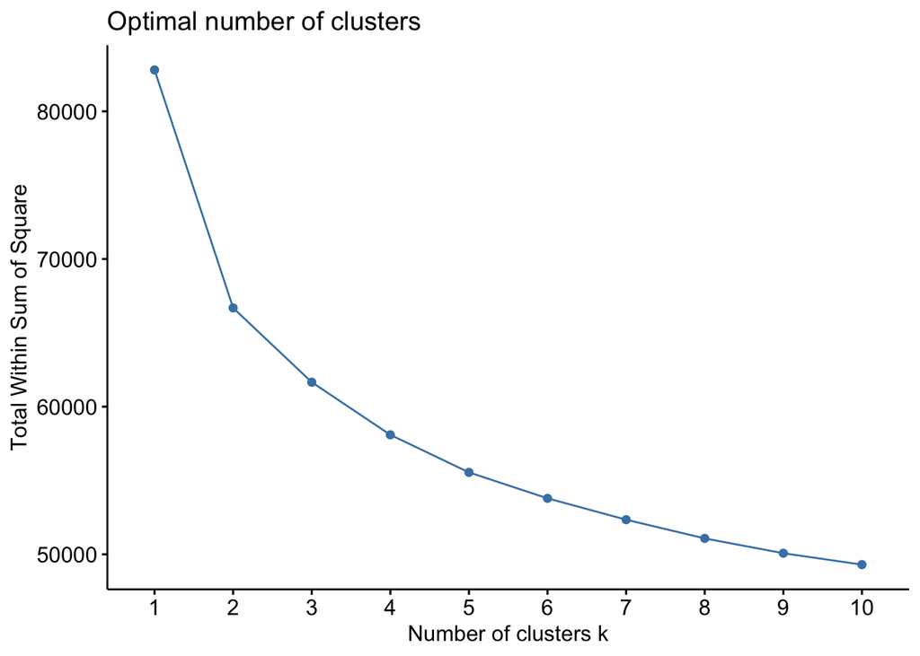

```r
#install.packages("factoextra")
library(factoextra)
fviz_nbclust(msq2, kmeans, method = "wss")
```

In this case is not very clear. Between 4 and 6 seems reasonable.

### Determine how many clusters continued

Instead of looking at the total within sum of squares, we can also consider how well each individual falls within one cluster (this becomes more complicated when individuals can be assigned to multiple clusters). The “silhouette” method helps evaluate this consistency within the clusters.

Given a certain cluster $k$, it determines how similar an individual is to its assigned cluster compared to other clusters. We want to have a maximum internal cohesion and separation compared to other clusters, that is a maximum average silhouette width.

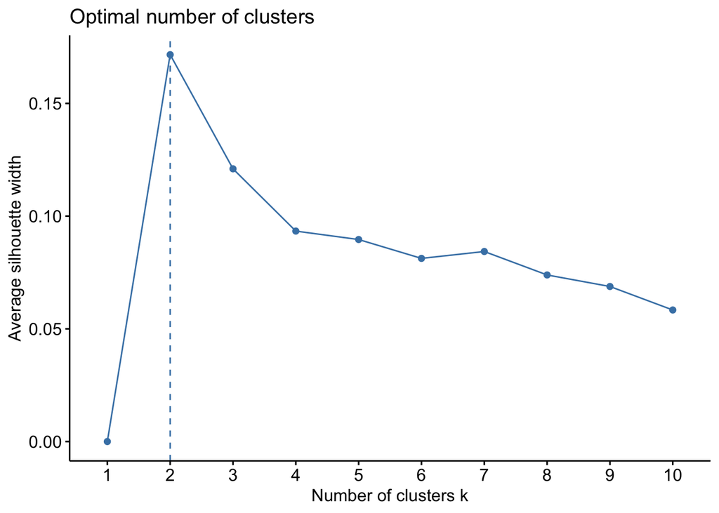

```r
fviz_nbclust(msq2, kmeans, method = "silhouette") #fviz_nbclust is part of the factoextra package that we loaded earlier.
```

This method suggest that two is the optimal number of clusters. But, what about the tranquil/calm cluster? As you can see, the *optimal* number of cluters based on purely numerical methods are simply suggestions and really a starting point. You have the liberty to specify a different amount of clusters if you have a sound theoretical reason.

## Kmeans with psych data visualized

Visualizing the clusters two-dimensionally in `R` using the `fviz_cluster` is very simple:

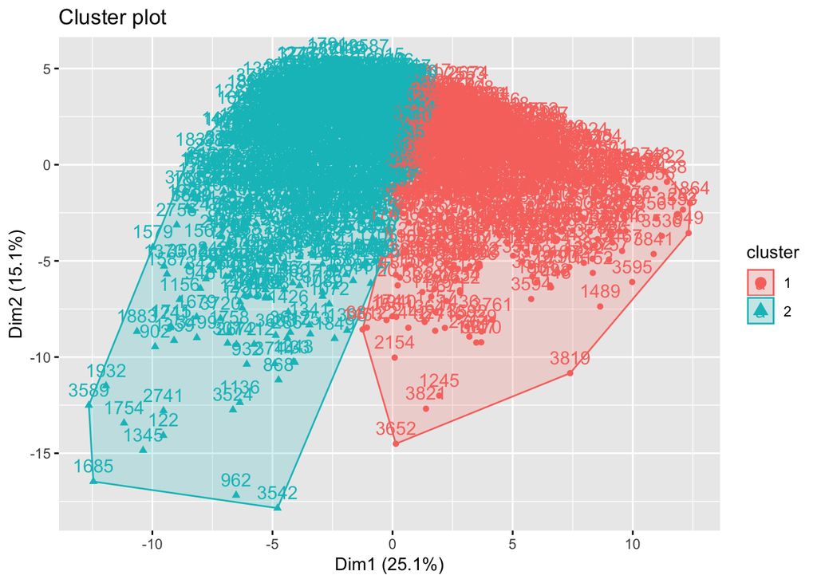

```r
fviz_cluster(kout, data=msq2)
```

You can also create a similar graph using `ggplot` as in the manual example. Let’s see how the graph looks like with three centers:

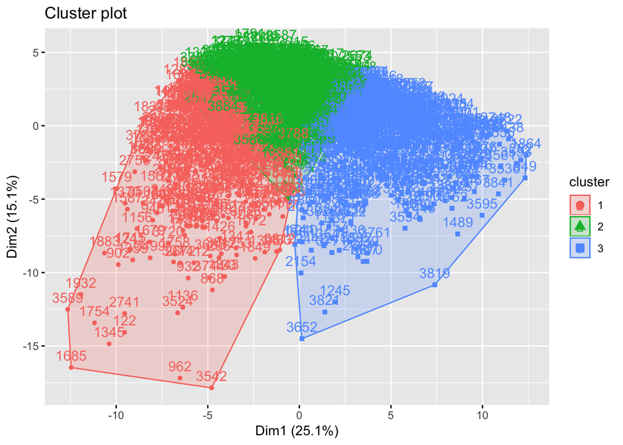

```r
fviz_cluster(kout3, data=msq2)
```

Now we can see that the third category emerges in the intersection of the two original clusters. Remember that we had “positive” and “negative” emotions, the third seems to be “neutral” emotions then. There is still seems to be some overlap between the three groups.

## Hierarchical clustering

- Hierarchical clustering is another method to create clusters of observations.
- It is also particularly helpful for a cluster analysis with categorical data (whereas kmeans works better with numerical data).
- Unlike k means, hierarchical clustering assembles clusters piece by piece: first a few similar observations are joined into a multitude of small clusters, and then similar small clusters are attached together to form alarger, on and upward until everything is just one cluster.
- For example, you can start with each observation being a cluster. Then, joining the data in pairs by their level of similarity. Then compute the mean of each cluster and keep joining clusters by how similar they are until you need up with a single cluster. You are, of course, in each step saving to what group each observation belongs to in each step. This allow us to create a hierarchy of cluster assignments.

### Similarity versus dissimilarity

**Similarity:**

- The key idea with hierarchical clustering is “similarity” – we join similar observations, and then similar clusters, until we’ve joined everything.
- Similarity between observations is simple enough: if we just take the distance between two observations (ie, the Euclidean distance), that’s a pretty good measure of similarity.

**Dissimilarity:**

- How do we measure the similarity between two small clusters, or between a cluster and a single observation we are considering adding to it?
- As usual, it turns out there are multiple answers to this question. It’s easiest to define them in terms of dissimilarity, which is just the inverse of similarity (ie, we will join clusters with the lowest dissimilarity).
  - *Complete*: the dissimilarity between two clusters A and B is equal to the largest distance between a member of group A and a member of group B.
  - *Single*: like Complete, but sets the dissimilarity between A and B to the *smallest* distance between a member of A and a member of B.
  - *Average*: the average dissimilarity between every member of A and every member of B.
  - *Centroid*: the distance between the centroid of A and the centroid of B.

## Hierarchical clustering in R

A simple R function for hierarchical clustering, `hclust()`.

Here’s `hclust` run on the simulated data. We’ll use the “average” method as a reasonable middle ground among the four distance methods.  
First though, we need to calculate the complete matrix of distances between every observation and every other one using the `dist()` function.

```r
hout <- hclust(dist(data[,1:2]),method="average")
```

### R continued

The easiest way to visualize the results are via a plot of the *dendrogram*:

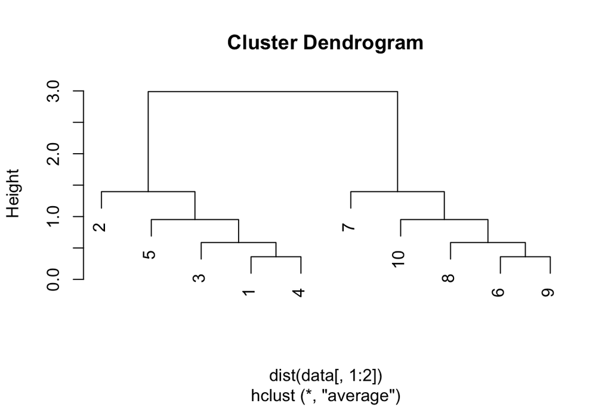

```r
plot(hout)
```

- Observations and clusters are joined together going from bottom to top, where the height where any two clusters join is equal to the dissimilarity between those two clusters.
- As one can see from this plot, each observation have a *cluster*, that it belongs to. The dendogram shows the process in which the data was joined together in clusters from the individual observations. For example, observations 6 and 9, and, 1 and 4, seems to be very similar with each other so they were joined together “earlier”. Then to the cluster with 6 and 9, 8 was added, etc., etc.
- Each observation at the end is classify into two big clusters, this reflects the fact that these data are tightly grouped into two main clusters that are much more different from each other than any subsets of those clusters are from each other. The height in the dendogram shows the dissimilarity between clusters. Then, to identify clusters we generally want to use the taller classifications.

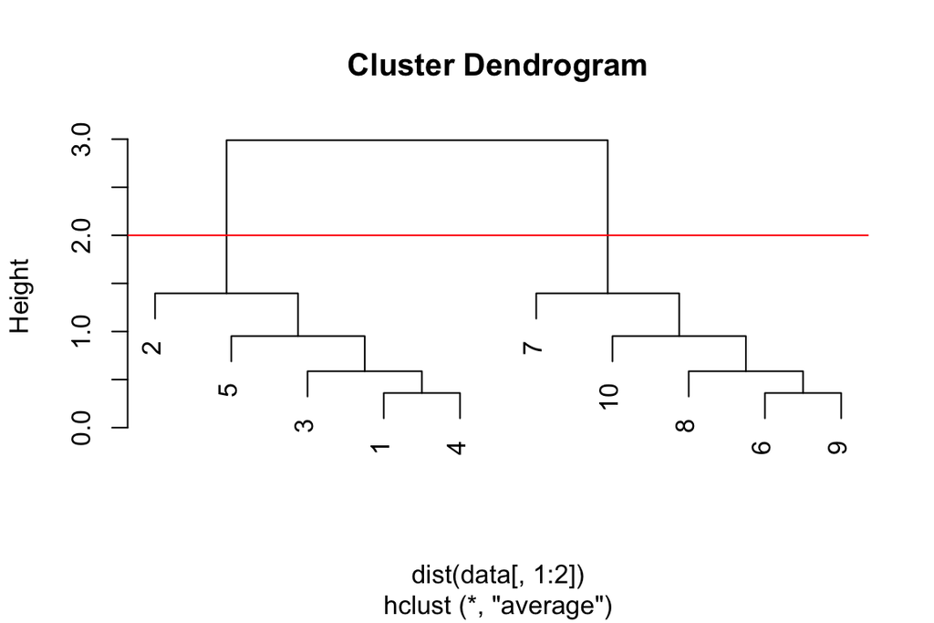

```r
plot(hout)
abline(a=2,b=0,col="red")
```

### R continued

To get the cluster assignments, we just apply `cutree` to the hclust output, choose either the height to cut it at, or the number of clusters:

```r
as.vector(cutree(hout,h=2))
```

```
 [1] 1 1 1 1 1 2 2 2 2 2
```

**So how do we choose where to make the cut – ie, the old question: how do we choose k?**

- There’s still no good answer, but there are rules of thumb: you can make the cut in a wide stretch, when there’s a big jump in distance before the next set of clusters are grouped together.
- Again, while that’s clear for this artificial data, it’s much less clear in many real cases – and there may be no “real” answer to determine.
- Perhaps we should think of clusters not as exclusive things, but as something that observations can have multiple and partial memberships with. Again, you can be happy and tired.

## Psych example

To conclude, here’s hclust applied to the MSQ data:

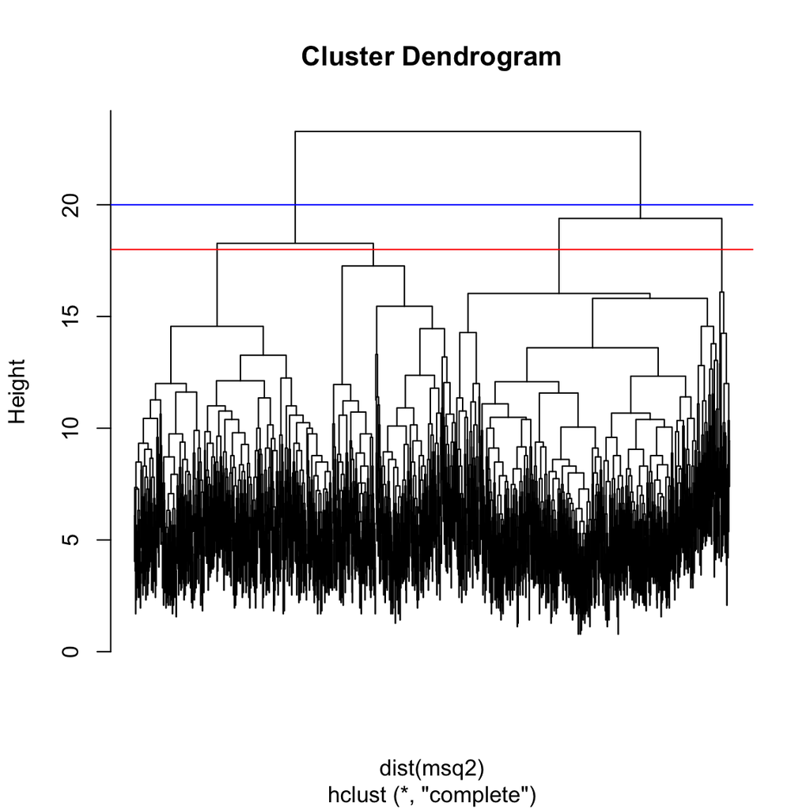

```r
hout2 <- hclust(dist(msq2),method="complete")
plot(hout2,labels=FALSE)
abline(a=18,b=0,col="red")
abline(a=20,b=0,col="blue")
```

- Two plausible places to make the cut are shown with the blue and red lines, which divide the tree into 2 and 4 clusters respectively.
- Whether we prefer 2 or 4, or something in between, or something more numerous, is ultimately up to the judgment of the researcher based on her substantive knowledge of the results.

Let’s see how the clusters using k-means looks like if we use 4 centers instead of three.

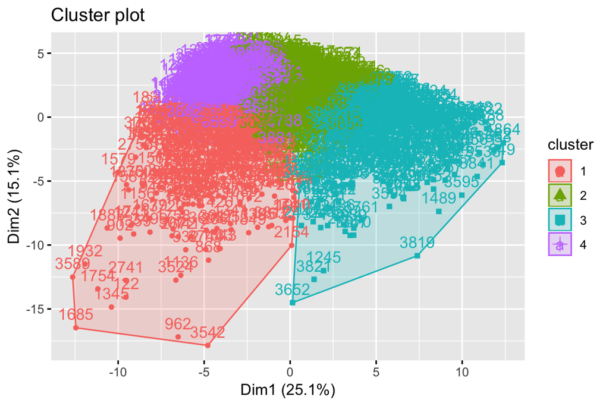

```r
kout4 <- kmeans(msq2, centers = 4, nstar = 100)
fviz_cluster(kout4, data=msq2)
```

```r
out <- sapply(1:4, FUN = function(x) round(colMeans(msq2[kout4$cluster == x,]),2))
clusterVars <- apply(out, 1, FUN = function(x) which(x == max(x)))

# This are the variables that score high
# for cluster 1
colnames(msq2)[clusterVars == 1]
```

```
 [1] "afraid"      "angry"       "anxious"     "ashamed"     "blue"
 [6] "bored"       "clutched.up" "depressed"   "distressed"  "drowsy"
[11] "dull"        "fearful"     "frustrated"  "gloomy"      "grouchy"
[16] "guilty"      "hostile"     "idle"        "irritable"   "lonely"
[21] "nervous"     "quiet"       "sad"         "scared"      "sleepy"
[26] "sluggish"    "sorry"       "tense"       "tired"       "unhappy"
[31] "upset"
```

```r
# This are the variables that score high
# for cluster 2
colnames(msq2)[clusterVars == 2]
```

```
[1] "at.ease"   "at.rest"   "calm"      "placid"    "quiescent" "relaxed"
[7] "serene"    "still"     "tranquil"
```

```r
# This are the variables that score high
# for cluster 3
colnames(msq2)[clusterVars == 3]
```

```
 [1] "alert"        "aroused"      "astonished"   "attentive"
 [5] "cheerful"     "confident"    "content"      "delighted"
 [9] "determined"   "elated"       "energetic"    "enthusiastic"
[13] "excited"      "full.of.pep"  "happy"        "inspired"
[17] "intense"      "interested"   "jittery"      "lively"
[21] "pleased"      "proud"        "satisfied"    "sociable"
[25] "strong"       "surprised"    "vigorous"     "wakeful"
[29] "warmhearted"  "wide.awake"
```

```r
# This are the variables that score high
# for cluster 4
colnames(msq2)[clusterVars == 4]
```

```
[1] "inactive"
```

Nothing new really. We simply found that those individuals that are *inactive* are different than the *tranquil/serene/calm* group.

### Nittygritty of things

- Someone has done an excellent job describing the steps and covering k-means clustering in more detail [here](https://uc-r.github.io/kmeans_clustering). It’s a very interesting analysis with data about crime.